# Week 3: Smoothing, Part 1

Xuan Pham

9/3/2019

# Time Series Components

```r
library(fpp2)
```

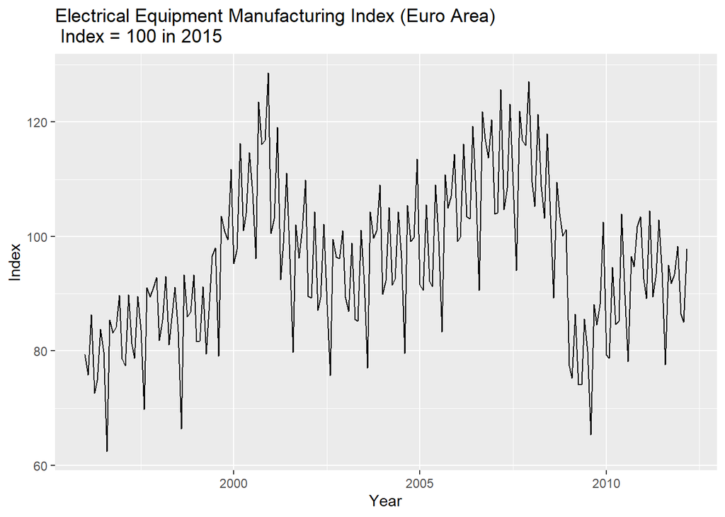

```r
#?elecequip Always look up a preloaded data set to learn more!
autoplot(elecequip) + xlab("Year") + ylab("Index") +
  ggtitle("Electrical Equipment Manufacturing Index (Euro Area) \n Index = 100 in 2015")
```

First, some EDA…

Step 1: Viewing the time series

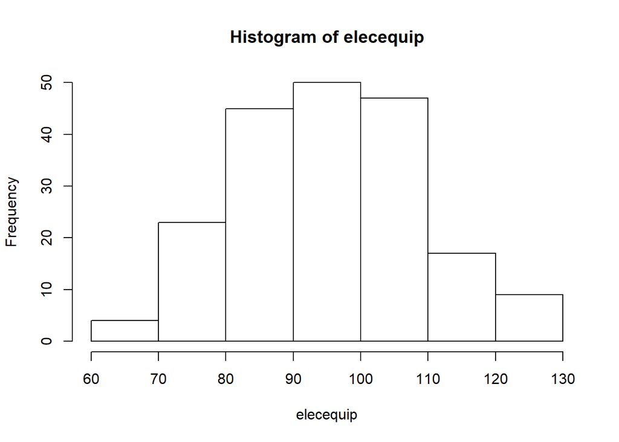

```r
hist(elecequip)
```

```r
library(fBasics)
basicStats(elecequip)
```

```
##                elecequip
## nobs          195.000000
## NAs             0.000000
## Minimum        62.410000
## Maximum       128.610000
## 1. Quartile    86.125000
## 3. Quartile   104.045000
## Mean           95.685487
## Median         94.680000
## Sum         18658.670000
## SE Mean         0.945718
## LCL Mean       93.820279
## UCL Mean       97.550696
## Variance      174.404497
## Stdev          13.206229
## Skewness        0.181427
## Kurtosis       -0.358091
```

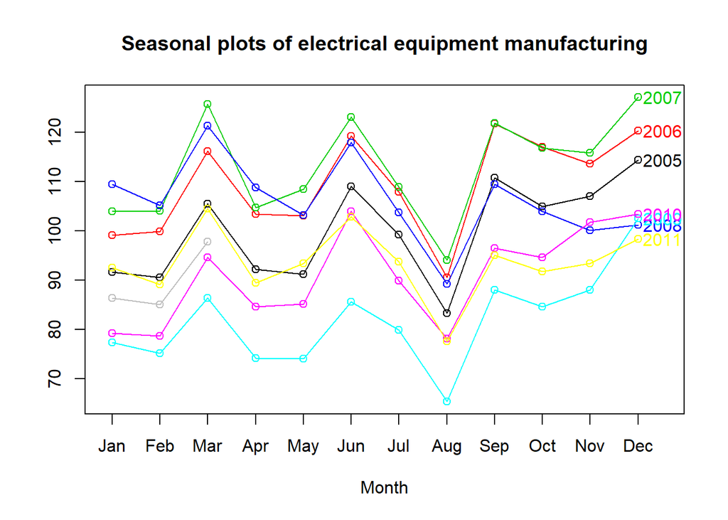

```r
library(forecast)
seasonplot(window(elecequip,start = 2005), year.labels = TRUE, col = 1:10, main = "Seasonal plots of electrical equipment manufacturing") #start at base year of index.
```

```r
library(xts)
elecequip_xts <- as.xts(elecequip)
last(elecequip_xts, '2 years')
```

```
##            [,1]
## Jan 2011  92.57
## Feb 2011  89.16
## Mar 2011 104.48
## Apr 2011  89.45
## May 2011  93.40
## Jun 2011 102.90
## Jul 2011  93.77
## Aug 2011  77.58
## Sep 2011  95.04
## Oct 2011  91.77
## Nov 2011  93.37
## Dec 2011  98.34
## Jan 2012  86.44
## Feb 2012  85.04
## Mar 2012  97.80
```

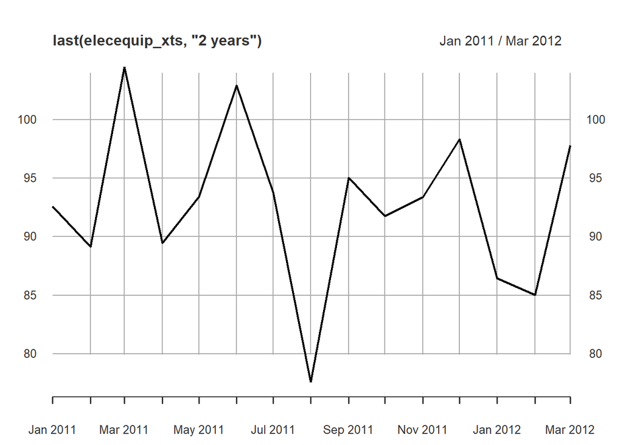

```r
plot(last(elecequip_xts, '2 years'))
```

Side Note: Here’s the xts cheat sheet from DataCamp: https://www.datacamp.com/community/blog/r-xts-cheat-sheet.

Step 2: Four moments

```r
library(moments)
```

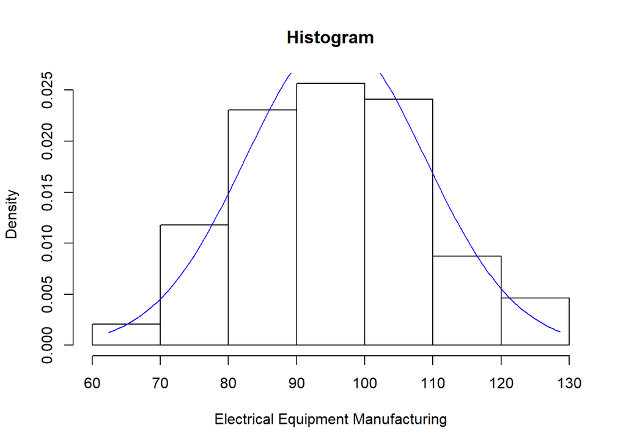

```r
hist(elecequip, xlab="Electrical Equipment Manufacturing", prob=TRUE, main="Histogram")
xfit<-seq(min(elecequip),max(elecequip), length=192)
yfit<-dnorm(xfit,mean=mean(elecequip),sd=sd(elecequip))
lines(xfit, yfit, col="blue", lwd=1)
```

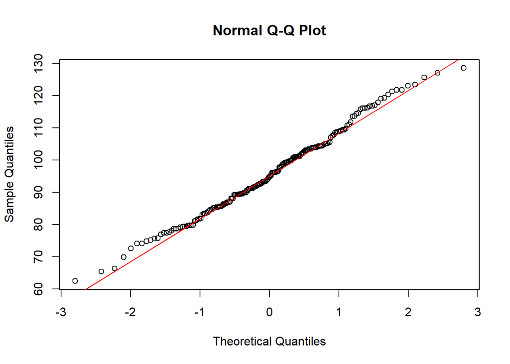

```r
qqnorm(elecequip)
qqline(elecequip, col = 2)
```

```r
skewness(elecequip)
```

```
## [1] 0.1828314
```

```r
kurtosis(elecequip)
```

```
## [1] 2.669215
```

```r
# NORMALITY TESTS
# Perform Jarque-Bera normality test.
#H0: Data is normally distributed
#H1: Data is not normally distributed
normalTest(elecequip,method=c("jb"))
```

```
##
## Title:
##  Jarque - Bera Normalality Test
##
## Test Results:
##   STATISTIC:
##     X-squared: 1.9754
##   P VALUE:
##     Asymptotic p Value: 0.3724
##
## Description:
##  Tue Sep 03 17:39:09 2019 by user: Xuan Pham
```

```r
#Since p-value > 0.05, we fail to reject H0. Data is normally distributed.
```

Now let’s look at the serial correlation in this time series.

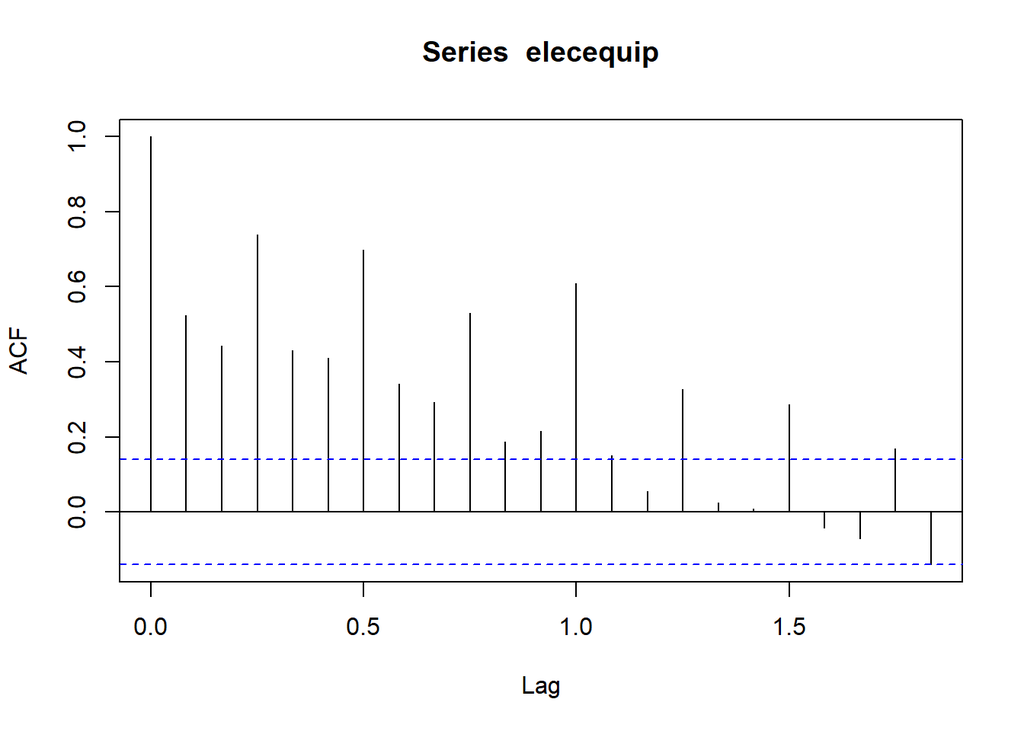

```r
acf(elecequip)
```

```r
# COMPUTE LJUNG-BOX TEST FOR WHITE NOISE (NO AUTOCORRELATION)
#H0: p(1) = p(2) = p(k) = 0
#H1: p(k) is not equal to 0

Box.test(elecequip,lag=12,type='Ljung')
```

```
##
##  Box-Ljung test
##
## data:  elecequip
## X-squared = 567, df = 12, p-value < 2.2e-16
```

```r
#Since p value < 0.05, we reject H0. There is serial autocorrelation!
```

## Digression

What would have happened if the JB test shows the data is not normally distributed? What can we do?

- logarithmic transformation
- power transformation (squared, cubed, etc.)
- Box-Cox transformation https://otexts.com/fpp2/transformations.html

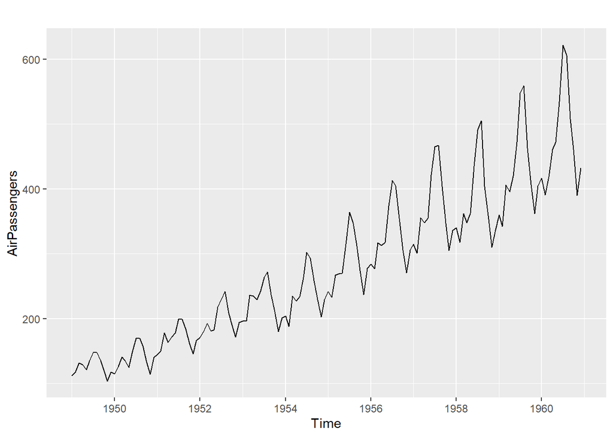

```r
autoplot(AirPassengers)
```

```r
normalTest(AirPassengers,method=c("jb")) #reject H0. Not normal dist.
```

```
##
## Title:
##  Jarque - Bera Normalality Test
##
## Test Results:
##   STATISTIC:
##     X-squared: 8.9225
##   P VALUE:
##     Asymptotic p Value: 0.01155
##
## Description:
##  Tue Sep 03 17:39:09 2019 by user: Xuan Pham
```

```r
BoxCox.lambda(AirPassengers)
```

```
## [1] -0.2947156
```

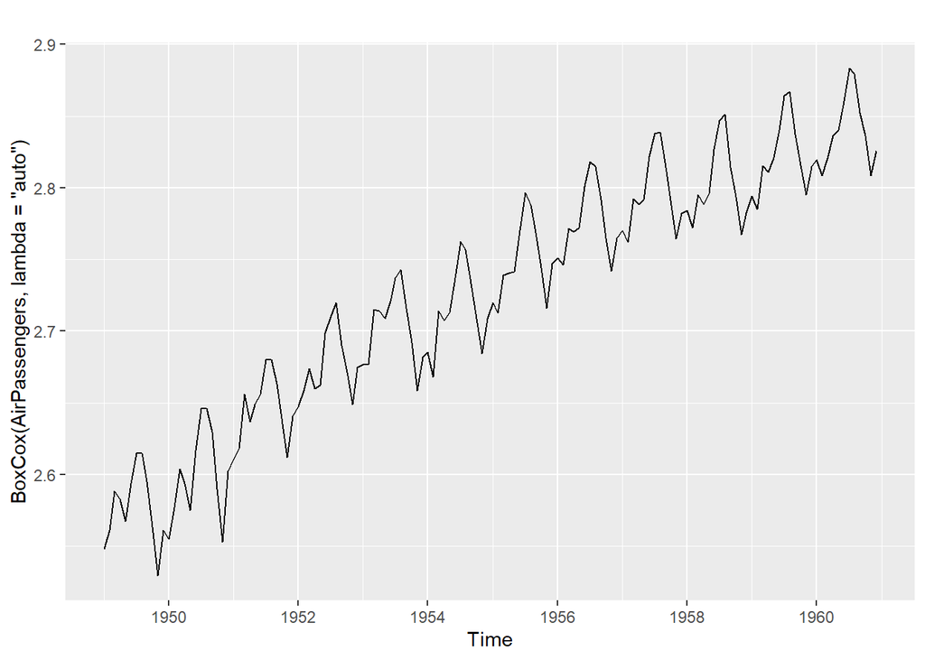

```r
autoplot(BoxCox(AirPassengers, lambda="auto")) #automate
```

```r
normalTest(BoxCox(AirPassengers,lambda="auto"), method=c("jb")) #reject H0
```

```
##
## Title:
##  Jarque - Bera Normalality Test
##
## Test Results:
##   STATISTIC:
##     X-squared: 7.2475
##   P VALUE:
##     Asymptotic p Value: 0.02668
##
## Description:
##  Tue Sep 03 17:39:10 2019 by user: Xuan Pham
```

How does this compare to taking the natural log?

```r
#?AirPassengers
AirPassengers_log <- log(AirPassengers)
normalTest(AirPassengers_log, method=c("jb")) #perhaps normal now?
```

```
##
## Title:
##  Jarque - Bera Normalality Test
##
## Test Results:
##   STATISTIC:
##     X-squared: 6.0199
##   P VALUE:
##     Asymptotic p Value: 0.04929
##
## Description:
##  Tue Sep 03 17:39:10 2019 by user: Xuan Pham
```

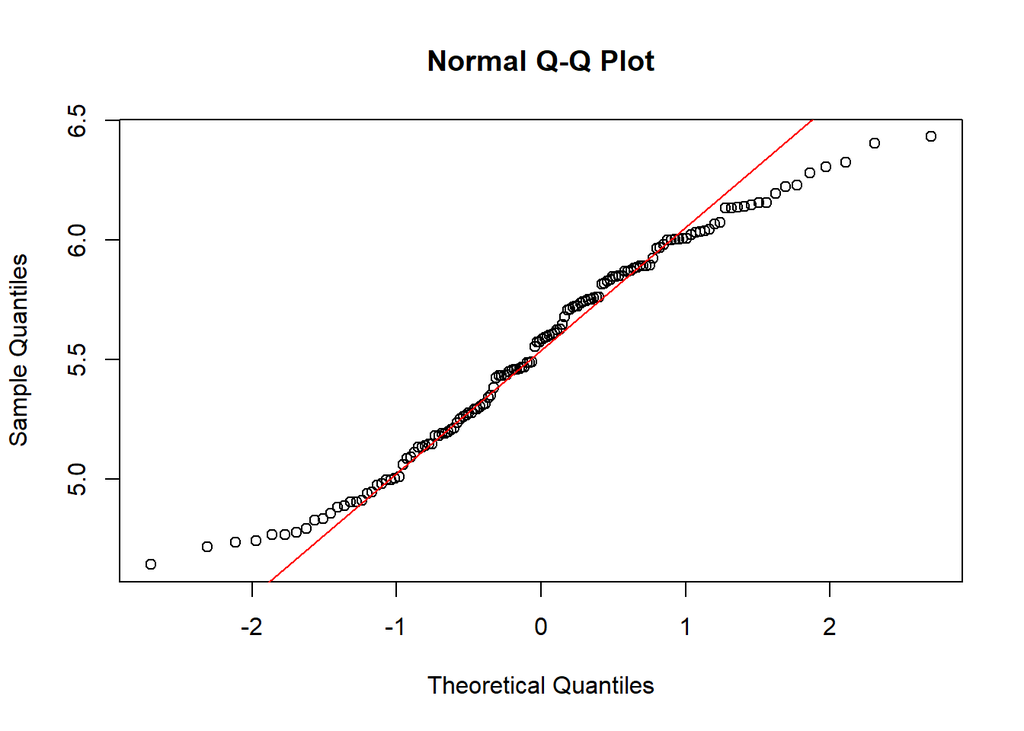

```r
qqnorm(AirPassengers_log)
qqline(AirPassengers_log, col = 2)
```

Can you identify the components of this time series?

Trend: Pattern exists when there is a long-term increase or decrease in the data.

Cyclical: Pattern exists when data exhibit rises and falls that are *not of fixed period* (duration usually of at least 2 years).

Seasonal: Pattern exists when a series is influenced by seasonal factors (e.g., the quarter of the year, the month, or day of the week).

# Smoothing

## Approach 1: Moving Average (MA)

```r
ma(elecequip, order=12)
```

```
##            Jan       Feb       Mar       Apr       May       Jun       Jul
## 1996        NA        NA        NA        NA        NA        NA  79.75042
## 1997  81.82958  82.29875  82.84333  83.34333  83.89125  84.30792  84.57458
## 1998  86.32292  86.17125  86.12208  86.07000  85.74792  85.58958  85.59583
## 1999  86.17625  87.31333  88.27083  89.32000  90.46792  91.76333  93.10542
## 2000 102.21458 103.32375 104.86250 106.32792 107.69000 109.11792 110.03750
## 2001 109.00875 107.84667 106.27042 104.54667 103.06583 101.63417 100.39250
## 2002  95.24417  94.74250  94.46625  94.36750  94.16417  93.58292  93.20667
## 2003  92.14708  92.35417  92.61042  92.95083  93.29333  93.83083  94.18667
## 2004  96.73042  97.02250  97.17667  97.20000  97.12375  97.25958  97.52292
## 2005  97.95125  98.23583  98.61708  99.08125  99.62583  99.96542 100.31375
## 2006 105.43417 106.09708 106.85667 107.82167 108.60500 109.13042 109.57792
## 2007 111.83375 112.01833 112.16667 112.15750 112.23500 112.60708 113.11917
## 2008 112.33375 111.92000 111.20417 110.15542 108.96625 107.22833 104.81042
## 2009  89.06083  87.07042  85.18208  83.48083  82.17042  81.72500  81.86000
```

[output cut: 21 more lines]

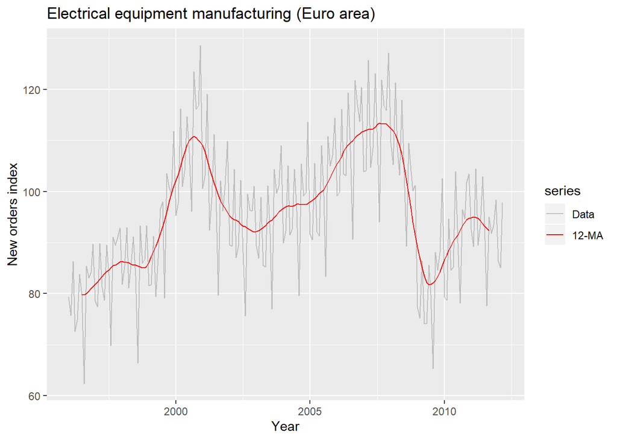

```r
autoplot(elecequip, series="Data") +
  autolayer(ma(elecequip, 12), series="12-MA") +
  xlab("Year") + ylab("New orders index") +
  ggtitle("Electrical equipment manufacturing (Euro area)") +
  scale_colour_manual(values=c("Data"="grey","12-MA"="red"),
                      breaks=c("Data","12-MA"))
```

What difference(s) do you see with this smoothing method?

```r
ma(elecequip, 12, centre = FALSE)
```

```
##            Jan       Feb       Mar       Apr       May       Jun       Jul
## 1996        NA        NA        NA        NA        NA  79.78000  79.72083
## 1997  81.99083  82.60667  83.08000  83.60667  84.17583  84.44000  84.70917
## 1998  86.31417  86.02833  86.21583  85.92417  85.57167  85.60750  85.58417
## 1999  86.78167  87.84500  88.69667  89.94333  90.99250  92.53417  93.67667
## 2000 102.61583 104.03167 105.69333 106.96250 108.41750 109.81833 110.25667
## 2001 108.53000 107.16333 105.37750 103.71583 102.41583 100.85250  99.93250
## 2002  94.91083  94.57417  94.35833  94.37667  93.95167  93.21417  93.19917
## 2003  92.30000  92.40833  92.81250  93.08917  93.49750  94.16417  94.20917
## 2004  96.91417  97.13083  97.22250  97.17750  97.07000  97.44917  97.59667
## 2005  98.07833  98.39333  98.84083  99.32167  99.93000 100.00083 100.62667
## 2006 105.79583 106.39833 107.31500 108.32833 108.88167 109.37917 109.77667
## 2007 111.87333 112.16333 112.17000 112.14500 112.32500 112.88917 113.34917
## 2008 112.12000 111.72000 110.68833 109.62250 108.31000 106.14667 103.47417
## 2009  88.06667  86.07417  84.29000  82.67167  81.66917  81.78083  81.93917
```

[output cut: 21 more lines]

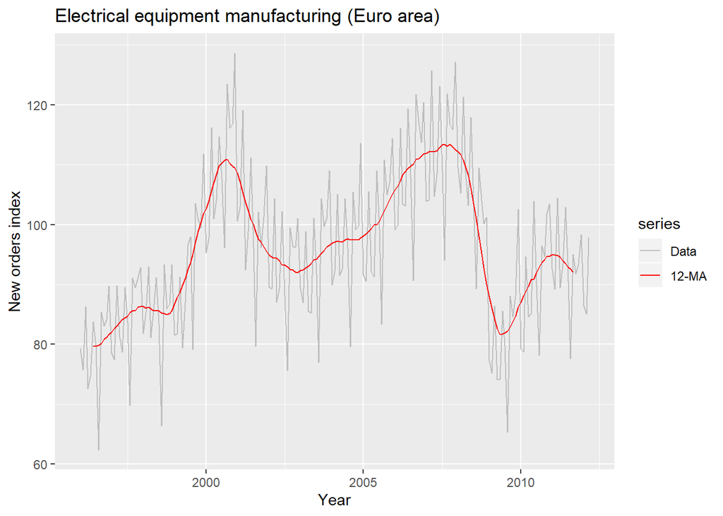

```r
autoplot(elecequip, series="Data") +
  autolayer(ma(elecequip, 12, centre=FALSE), series="12-MA") +
  xlab("Year") + ylab("New orders index") +
  ggtitle("Electrical equipment manufacturing (Euro area)") +
  scale_colour_manual(values=c("Data"="grey","12-MA"="red"),
                      breaks=c("Data","12-MA"))
```

## Quick Exercise

Change the MA to 3, 6, 9, and 24 periods. What differences do you see?

## Time series decomposition

- Additive model appropriate if magnitude of seasonal fluctuations does not vary with level.
- If seasonal are proportional to level of series, then multiplicative model appropriate.
- Multiplicative decomposition more prevalent with economic series
- Logs turn multiplicative relationship into an additive relationship:

Let’s look at some plots.

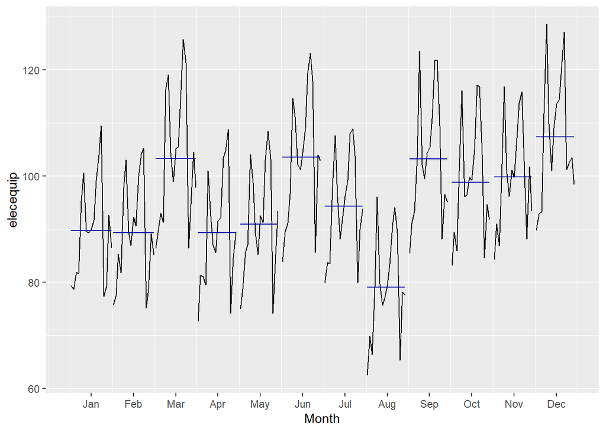

```r
ggsubseriesplot(elecequip)
```

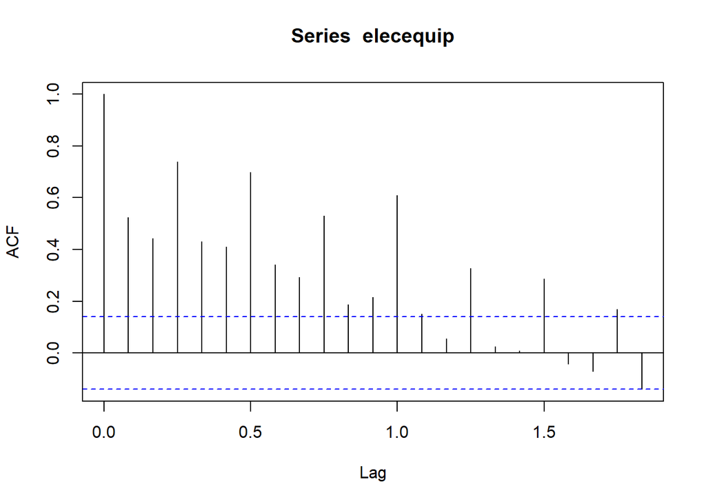

```r
acf(elecequip)
```

#Multiplicative Decomposition

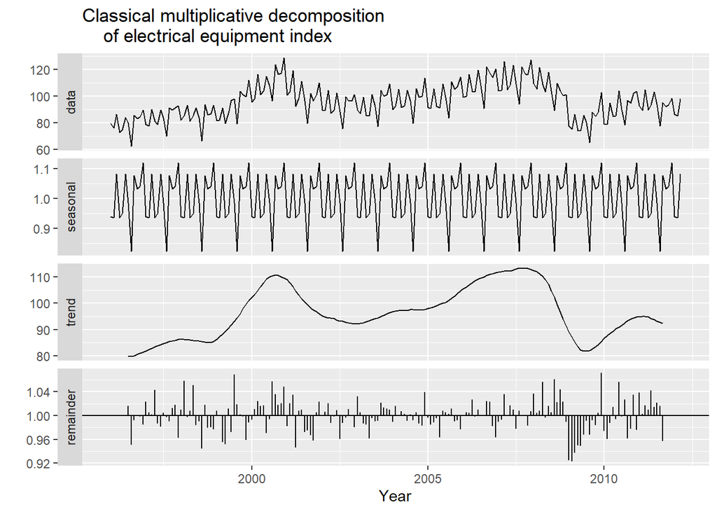

```r
elecequip %>% decompose(type="multiplicative") %>%
  autoplot() + xlab("Year") +
  ggtitle("Classical multiplicative decomposition
    of electrical equipment index")
```

How does the Multiplicative Decomposition Model do in “smoothing” the time series? Do you see any problem in the remainder component? Is it moving with any other component?

What’s wrong with classical decomposition?

## X11 & SEATS Decomposition

```r
library(seasonal)
```

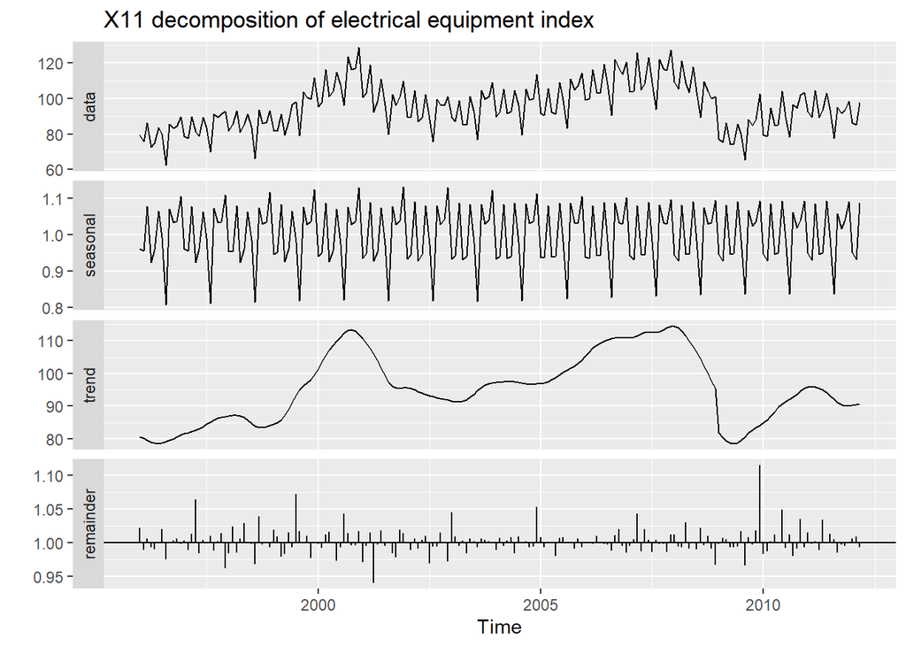

```r
fit.x11 <- seas(elecequip, x11="")
autoplot(fit.x11) +  ggtitle("X11 decomposition of electrical equipment index")
```

Advantages:

- Relatively robust to outliers
- Completely automated choices for trend and seasonal changes
- Very widely tested on economic data over a long period of time.

Disadvantages:

- No prediction/confidence intervals
- Ad hoc method with no underlying model
- Only developed for quarterly and monthly data

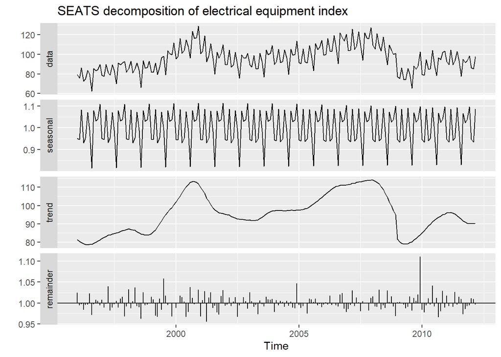

```r
library(seasonal)
fit.seats <- seas(elecequip)
autoplot(fit.seats) +
  ggtitle("SEATS decomposition of electrical equipment index")
```

### SEATS (SEASONAL EXTRACTION IN ARIMA Time Series)

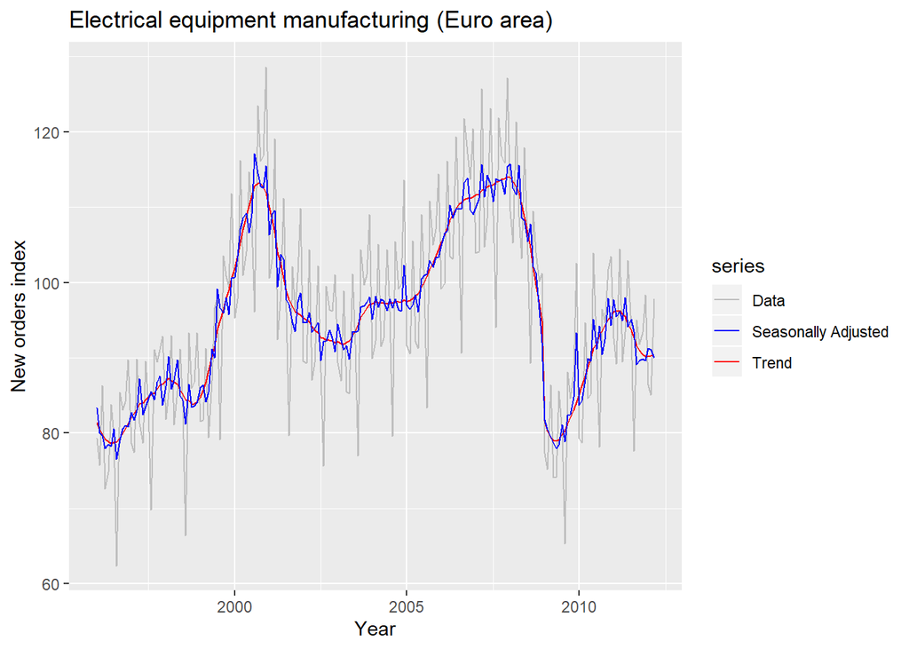

```r
autoplot(elecequip, series="Data") +
  autolayer(trendcycle(fit.seats), series="Trend") +
  autolayer(seasadj(fit.seats), series="Seasonally Adjusted") +
  xlab("Year") + ylab("New orders index") +
  ggtitle("Electrical equipment manufacturing (Euro area)") +
  scale_colour_manual(values=c("gray","blue","red"),
                     breaks=c("Data","Seasonally Adjusted","Trend"))
```

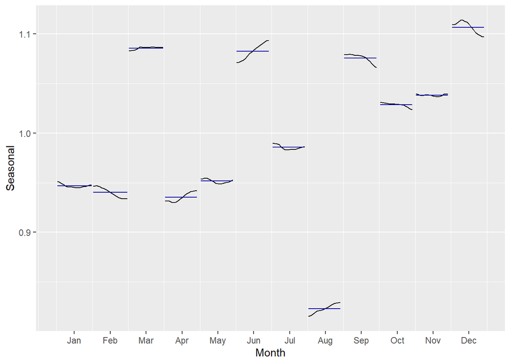

```r
ggsubseriesplot(seasonal(fit.seats)) + ylab("Seasonal")
```

Advantages: * Model-based * Smooth trend estimate * Allows estimates at end points * Allows changing seasonality * Developed for economic data

Disadvantage:  
* Only developed for quarterly and monthly data

## STL decomposition

- STL: “Seasonal and Trend decomposition using Loess”
- Very versatile and robust.
- STL will handle any type of seasonality.
- Seasonal component allowed to change over time, and rate of change controlled by user.
- Smoothness of trend-cycle also controlled by user.
- Robust to outliers
- Not trading day or calendar adjustments.
- Only additive.
- Take logs to get multiplicative decomposition.
- Use Box-Cox transformations to get other decompositions.

On STL algorithm: http://www.gardner.fyi/blog/STL-Part-II/  
On LOESS: http://r-statistics.co/Loess-Regression-With-R.html and http://varianceexplained.org/files/loess.html. ## STL decomposition (SEASONAL AND TREND DECOMPOSITION USING LOESS)

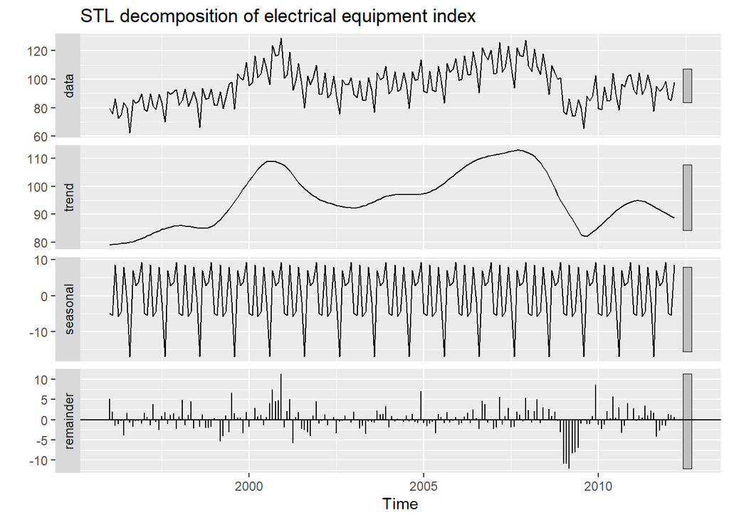

```r
#?stl
#look at the help file first
#`t.window` controls wiggliness of trend component. Default is defined in help file.
#`s.window` controls variation on seasonal component. periodic means to use the default period (month in this case) to calculate the seasonal components
fit <- stl(elecequip, s.window="periodic", robust=TRUE)
autoplot(fit) +
  ggtitle("STL decomposition of electrical equipment index")
```

Try out different s and t window values to see the different. Be sure to look at the ACF plot to see if you can identify the number of lags to use for the windows.

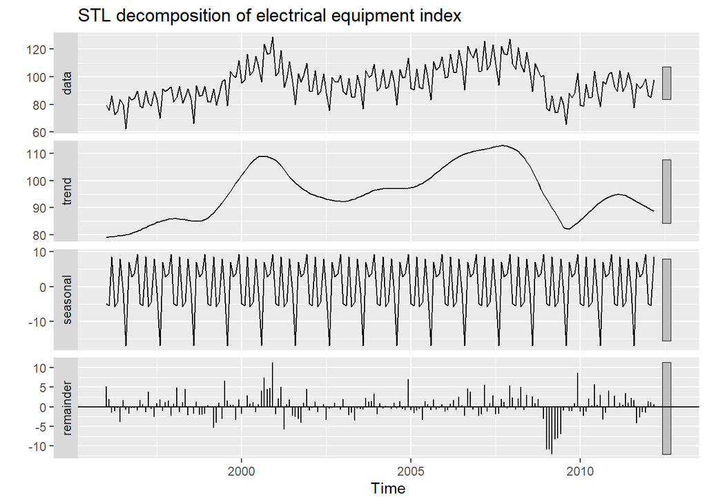

```r
fit <- stl(elecequip, s.window="periodic", t.window=NULL, robust=TRUE)
autoplot(fit) +
  ggtitle("STL decomposition of electrical equipment index")
```

Or we can try to “automate” the process:

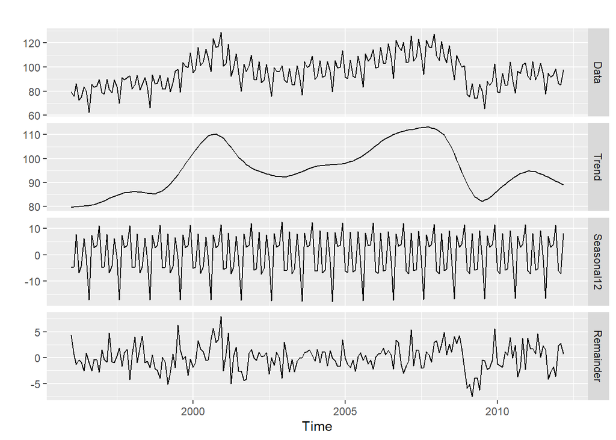

```r
elecequip %>% mstl() %>% autoplot()
```

For more information, see link: https://www.scb.se/contentassets/ca21efb41fee47d293bbee5bf7be7fb3/stl-a-seasonal-trend-decomposition-procedure-based-on-loess.pdf

## Forecasting and decomposition

- Forecast seasonal component by repeating the last year
- Forecast seasonally adjusted data using non-seasonal time series method.
- Combine forecasts of seasonal component with forecasts of seasonally adjusted data to get forecasts of original data.
- Sometimes a decomposition is useful just for understanding the data before building a separate forecasting model.

## Electrical equipment

```r
fit <- stl(elecequip, t.window=13, s.window="periodic")
```

We use the naive method to forecast the seasonally adjusted component (Trend, Cyclical, and Random) and seasonality component. The two components are added together to create a “reseasonalized” forecast.

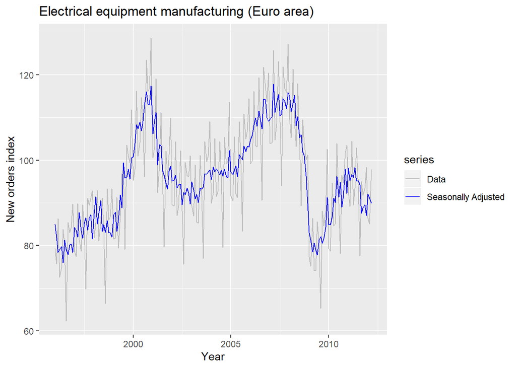

```r
autoplot(elecequip, series="Data") +
  autolayer(seasadj(fit), series="Seasonally Adjusted") +
  xlab("Year") + ylab("New orders index") +
  ggtitle("Electrical equipment manufacturing (Euro area)") +
  scale_colour_manual(values=c("gray","blue"),
                     breaks=c("Data","Seasonally Adjusted"))
```

Now let’s bring everything together to get forecasts

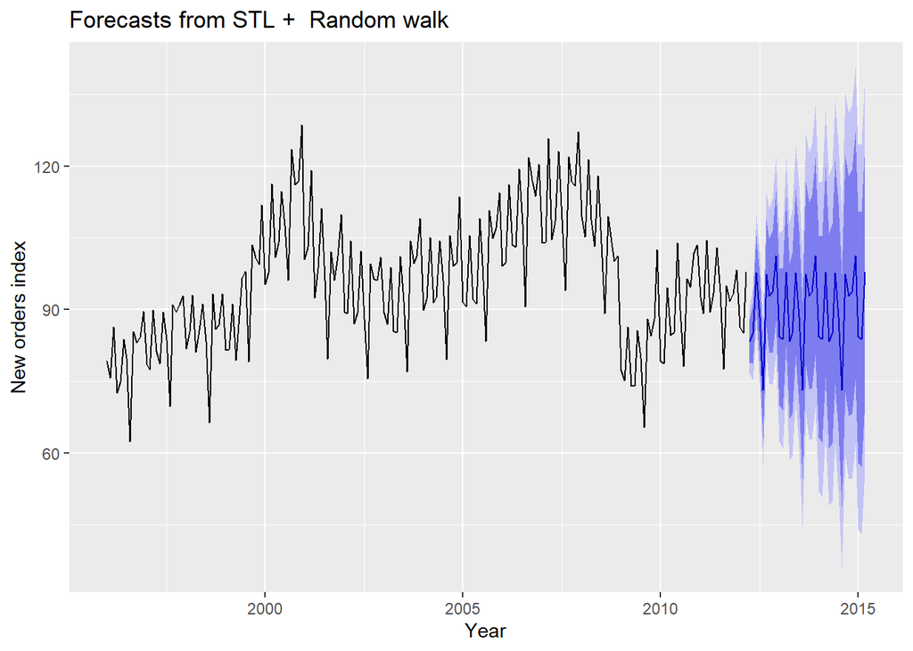

```r
fit %>% forecast(method='naive', h=36) %>%
  autoplot() + ylab("New orders index") + xlab("Year")
```

```r
summary(fit %>% forecast(method='naive'))
```

```
##
## Forecast method: STL +  Random walk
##
## Model Information:
## Call: rwf(y = x, h = h, drift = FALSE, level = level)
##
## Residual sd: 3.5154
##
## Error measures:
##                      ME     RMSE      MAE         MPE     MAPE     MASE
## Training set 0.02566723 3.506388 2.723322 -0.02484186 2.874973 0.333245
##                    ACF1
## Training set -0.3373772
##
## Forecasts:
##          Point Forecast    Lo 80     Hi 80    Lo 95     Hi 95
## Apr 2012       83.45798 78.96436  87.95159 76.58558  90.33037
## May 2012       85.04087 78.68593  91.39580 75.32184  94.75990
## Jun 2012       97.68151 89.89834 105.46469 85.77818 109.58485
## Jul 2012       88.46028 79.47305  97.44751 74.71549 102.20507
## Aug 2012       73.19696 63.14893  83.24499 57.82982  88.56410
## Sep 2012       97.41490 86.40783 108.42196 80.58104 114.24875
## Oct 2012       92.87455 80.98555 104.76354 74.69190 111.05719
## Nov 2012       93.74607 81.03621 106.45594 74.30801 113.18414
## Dec 2012      101.17630 87.69545 114.65715 80.55912 121.79348
## Jan 2013       84.32944 70.11938  98.53951 62.59703 106.06186
## Feb 2013       83.80002 68.89638  98.70366 61.00686 106.59317
## Mar 2013       97.80000 82.23366 113.36634 73.99333 121.60667
## Apr 2013       83.45798 67.25601  99.65994 58.67921 108.23674
## May 2013       85.04087 68.22729 101.85444 59.32673 110.75501
## Jun 2013       97.68151 80.27781 115.08522 71.06485 124.29818
## Jul 2013       88.46028 70.48581 106.43475 60.97071 115.94985
## Aug 2013       73.19696 54.66931  91.72462 44.86136 101.53257
## Sep 2013       97.41490 78.35009 116.47970 68.25780 126.57199
## Oct 2013       92.87455 73.28733 112.46177 62.91848 122.83062
## Nov 2013       93.74607 73.65001 113.84214 63.01180 124.48035
## Dec 2013      101.17630 80.58396 121.76864 69.68303 132.66956
## Jan 2014       84.32944 63.25251 105.40637 52.09506 116.56383
## Feb 2014       83.80002 62.24939 105.35064 50.84117 116.75886
## Mar 2014       97.80000 75.78586 119.81414 64.13229 131.46771
```

## Decomposition and prediction intervals

- It is common to take the prediction intervals from the seasonally adjusted forecasts and modify them with the seasonal component.
- This ignores the uncertainty in the seasonal component estimate.
- It also ignores the uncertainty in the future seasonal pattern.